# DATA 607 Assignment 10B

Joao De Oliveira

November 08, 2025

# 1 Overview

This report explores Nobel Prize data using the public JSON API provided by NobelPrize.org. The goal is to practice working with real-world JSON data in R while performing meaningful exploratory analysis. After retrieving and cleaning data I address four key questions: (1) Which countries have produced the most Nobel laureates by birth? (2) Which countries have “lost” the most laureates—those born there but affiliated elsewhere when awarded? (3) Which universities or research institutions most frequently appear as laureate affiliations? (4) How has the age of Nobel Prize recipients evolved over time by discipline and decade? Together, these analyses illustrate how JSON APIs can be leveraged to uncover insights into global scientific and cultural trends.

# 2 Study

```r
laureates_id <- laureates_raw %>%
  transmute(
    id = id,
    knownName = coalesce(knownName.en, fullName.en, orgName.en),
    givenName = givenName.en,
    familyName = familyName.en,
    gender = gender,
    birth_date = suppressWarnings(ymd(birth.date)),
    birth_country = coalesce(birth.place.country.en, birth.place.countryNow.en),
    death_date = suppressWarnings(ymd(death.date)),
    is_organization = if_else(!is.na(orgName.en), TRUE, FALSE)
  )


prizes_per_laureate <- laureates_raw %>%
  select(id, nobelPrizes) %>%
  tidyr::unnest(nobelPrizes, keep_empty = TRUE) %>%
  transmute(
    id = id,
    awardYear = suppressWarnings(as.integer(awardYear)),
    category = category.en,
    prizeStatus = prizeStatus,
    prizeAmount = prizeAmount,
    prizeAmountAdjusted = prizeAmountAdjusted,
    affiliations = affiliations
  )


affils <- prizes_per_laureate %>%
  mutate(row_id = dplyr::row_number()) %>%
  unnest(affiliations, keep_empty = TRUE) %>%
  transmute(
    row_id,
    affiliation_name   = name.en,
    affiliation_city   = city.en,
    affiliation_country = coalesce(country.en, countryNow.en)
  )


prizes_per_laureate <- prizes_per_laureate %>%
  mutate(row_id = dplyr::row_number()) %>%
  left_join(affils, by = "row_id") %>%
  select(-row_id)

# Combined table for analysis
laureate_prizes <- prizes_per_laureate %>%
  left_join(laureates_id, by = "id")
```

## 2.1 Which countries have the most Nobel laureates by birth?

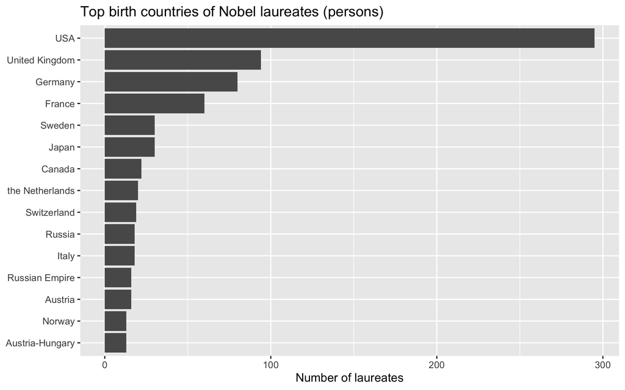

```r
q1 <- laureates_id %>%
  filter(is_organization == FALSE, !is.na(birth_country)) %>%
  distinct(id, birth_country) %>%
  count(birth_country, sort = TRUE) %>%
  slice_head(n = 15) %>%
  mutate(birth_country = fct_reorder(birth_country, n))

ggplot(q1, aes(n, birth_country)) +
  geom_col() +
  labs(
    title = "Top birth countries of Nobel laureates (persons)",
    x = "Number of laureates",
    y = NULL
  )
```

## 2.2 Which countries “lost” the most laureates?

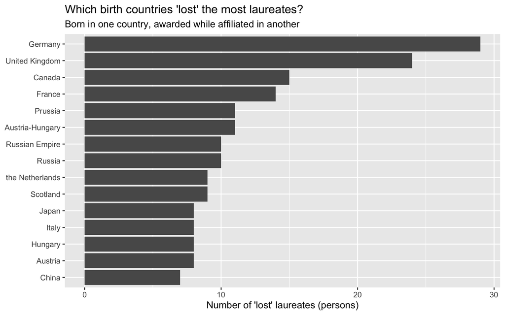

```r
person_affil <- laureate_prizes %>%
  filter(is_organization == FALSE) %>%
  filter(!is.na(affiliation_country), !is.na(birth_country))

lost_flags <- person_affil %>%
  mutate(lost = affiliation_country != birth_country) %>%
  group_by(id, birth_country) %>%
  summarise(lost_any = any(lost, na.rm = TRUE), .groups = "drop")

q2 <- lost_flags %>%
  filter(lost_any) %>%
  count(birth_country, sort = TRUE) %>%
  slice_head(n = 15) %>%
  mutate(birth_country = fct_reorder(birth_country, n))

ggplot(q2, aes(n, birth_country)) +
  geom_col() +
  labs(
    title = "Which birth countries 'lost' the most laureates?",
    subtitle = "Born in one country, awarded while affiliated in another",
    x = "Number of 'lost' laureates (persons)",
    y = NULL
  )
```

## 2.3 Which universities (affiliations) appear most often?

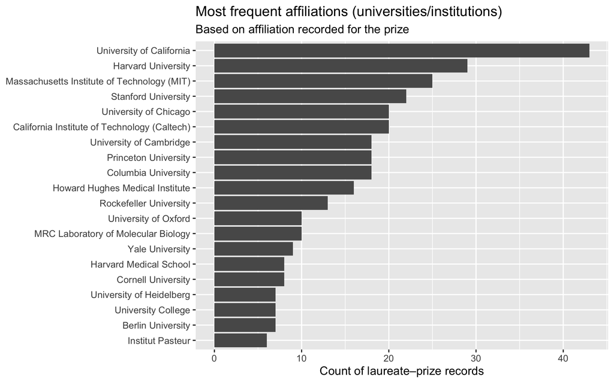

```r
top_affiliations <- laureate_prizes %>%
  filter(is_organization == FALSE) %>%
  filter(!is.na(affiliation_name)) %>%
  mutate(affiliation_name = str_squish(affiliation_name)) %>%
  filter(affiliation_name != "", affiliation_name != "—") %>%
  count(affiliation_name, sort = TRUE) %>%
  slice_head(n = 20) %>%
  mutate(affiliation_name = fct_reorder(affiliation_name, n))

ggplot(top_affiliations, aes(n, affiliation_name)) +
  geom_col() +
  labs(
    title = "Most frequent affiliations (universities/institutions)",
    subtitle = "Based on affiliation recorded for the prize",
    x = "Count of laureate–prize records",
    y = NULL
  )
```